# Homework 4

Author

Yifei Wang

GitHub repository: https://github.com/suyi-afk/stats506/tree/main/hw4

# Problem 1 - Tidyverse: New Zealand

## Load data

```r
library(tidyverse)
```

```r
nzge_url = "https://phuongov.github.io/stats506-f26/data_f26/nzge.rds"
if (!dir.exists('p1')) dir.create('p1')
if (!file.exists('./p1/nzge.rds')) download.file(nzge_url, './p1/nzge.rds')
```

```r
nzge <- readRDS("./p1/nzge.rds")
```

## Process data

1. Generate a table (which can just be a nicely printed tibble) of vote count (regardless of party) per year/type. Make sure to sort it by vote count.

```r
result.a <- nzge %>%
  select(election_year, voting_type, votes) %>%
  group_by(election_year, voting_type) %>%
  summarise(total_votes = sum(votes), .groups = "drop") %>%
  arrange(desc(total_votes))

tibble(result.a)
```

```
# A tibble: 10 × 3
   election_year voting_type total_votes
           <dbl> <chr>             <dbl>
 1          2014 Party           2416479
 2          2014 Candidate       2375493
 3          2008 Party           2356536
 4          2008 Candidate       2325598
 5          2005 Party           2286190
 6          2005 Candidate       2260670
 7          2011 Party           2257336
 8          2011 Candidate       2225766
 9          2002 Party           2040248
10          2002 Candidate       2022115
```

Focus only on the 2014 election. Report the proportion of votes for each party in the Candidate election. Again, produce a nice table and sort it by percent of vote.

```r
result.b <- nzge %>%
    filter(election_year == 2014, voting_type == "Candidate") %>%
    select(party, votes) %>%
    group_by(party) %>%
    summarise(total_votes = sum(votes), .groups = "drop") %>%
    arrange(desc(total_votes)) %>%
    mutate(vote_proportion = round(total_votes / sum(total_votes), 6)) %>%
    select(party, vote_proportion)

tibble(result.b)
```

```
# A tibble: 25 × 2
   party                    vote_proportion
   <chr>                              <dbl>
 1 National Party                   0.455
 2 Labour Party                     0.337
 3 Green Party                      0.0698
 4 Conservative Party               0.0341
 5 New Zealand First Party          0.0309
 6 Maori Party                      0.0177
 7 MANA Movement                    0.0136
 8 Informal Candidate Votes         0.0117
 9 ACT New Zealand                  0.0117
10 United Future                    0.00620
# ℹ 15 more rows
```

Produce a nice table indicating, for each year, which party won the Candidate vote and which party won the Party vote.

```r
result.c <- nzge %>%
  group_by(election_year, voting_type, party) %>%
  summarise(total_votes = sum(votes), .groups = "drop_last") %>%
  filter(total_votes == max(total_votes)) %>%
  select(election_year, voting_type, party) %>%
  pivot_wider(names_from = voting_type, values_from = party)

tibble(result.c)
```

```
# A tibble: 5 × 3
  election_year Candidate      Party
          <dbl> <chr>          <chr>
1          2002 Labour Party   Labour Party
2          2005 National Party Labour Party
3          2008 National Party National Party
4          2011 National Party National Party
5          2014 National Party National Party
```

# Problem 2 - Tidyverse: Tennis

## Load data

```r
library(tidyverse)
library(infer)
```

```r
atp_2019_url = paste(
    "https://raw.githubusercontent.com/azhou5849/tennis-atp-sackmann-data/",
    "refs/heads/master/atp_matches_2019.csv"
)
if (!dir.exists('p2')) dir.create('p2')
if (!file.exists('./p2/atp_matches_2019.csv'))
    download.file(atp_2019_url, './p2/atp_matches_2019.csv')
```

```r
atp_2019 <- read.csv('./p2/atp_matches_2019.csv')
```

## Process data

1. How many tournaments took place in 2019?

```r
atp_2019 %>% summarize(tourney_count = n_distinct(tourney_id))
```

```
  tourney_count
1           128
```

There are 128 tournaments took place in 2019.

2. Did any player win more than one tournament? If so, how many players won more than one tournament, and how many tournaments did the most winning player(s) win?

```r
atp_2019 %>%
    filter(round == "F") %>%
    group_by(winner_id, winner_name) %>%
    summarize(win_count = n_distinct(tourney_id), .groups = "drop") %>%
    filter(win_count > 1) %>%
    arrange(desc(win_count))
```

```
# A tibble: 12 × 3
   winner_id winner_name        win_count
       <int> <chr>                  <int>
 1    104925 Novak Djokovic             5
 2    106233 Dominic Thiem              5
 3    103819 Roger Federer              4
 4    104745 Rafael Nadal               4
 5    106421 Daniil Medvedev            4
 6    126774 Stefanos Tsitsipas         3
 7    200282 Alex De Minaur             3
 8    104542 Jo-Wilfried Tsonga         2
 9    105332 Benoit Paire               2
10    106401 Nick Kyrgios               2
11    106426 Cristian Garin             2
12    126610 Matteo Berrettini          2
```

There are 12 players who won more than one tournament. The most winning players are Novak Djokovic and Dominic Thiem, who both won 5 tournaments.

3. Is there any evidence that winners have more aces than losers? (If you address this with a hypothesis test, do not use base R functionality - continue to remain in the Tidyverse.)

```r
atp_2019 %>%
    select(w_ace, l_ace) %>%
    drop_na() %>%
    mutate(ace_diff = w_ace - l_ace) %>%
    summarise(
        n = n(),
        mean_diff = mean(ace_diff),
        se = sd(ace_diff) / sqrt(n),
        t_stat = mean_diff / se,
        p_value = pt(t_stat, df = n - 1, lower.tail = FALSE)
    )
```

```
     n mean_diff        se   t_stat      p_value
1 2694    1.7049 0.1377917 12.37302 1.530201e-34
```

Since p < 0.001, there is strong evidence that winners have more aces than losers on average.

4. Identify the player(s) with the highest win-rate. (Note that this is NOT asking for the highest number of wins.) Restrict to players with at least 5 matches.

```r
bind_rows(
    atp_2019 %>%
        select(winner_id, winner_name) %>%
        mutate(
            id = winner_id,
            name = winner_name,
            win = TRUE
        ) %>%
        select(id, name, win),
    atp_2019 %>%
        select(loser_id, loser_name) %>%
        mutate(
            id = loser_id,
            name = loser_name,
            win = FALSE
        ) %>%
        select(id, name, win)
) %>%
    group_by(id, name) %>%
    summarise(total_game = n(), win_rate = mean(win), .groups = "drop") %>%
    filter(total_game >= 5) %>%
    arrange(desc(win_rate)) %>%
    mutate(win_rate = round(win_rate, 4)) %>%
    slice_head(n = 5)
```

```
# A tibble: 5 × 4
      id name            total_game win_rate
   <int> <chr>                <int>    <dbl>
1 104745 Rafael Nadal            69    0.870
2 104925 Novak Djokovic          69    0.841
3 103819 Roger Federer           66    0.833
4 106421 Daniil Medvedev         80    0.738
5 104731 Kevin Anderson          15    0.733
```

Rafael Nadal has the highest win-rate with 86.96% after attending 69 matches.

# Problem 3 - Visualization

## Load data

```r
library(tidyverse)
library(ggplot2)
library(slider)
library(ggrepel)
```

```r
covid19_url = paste(
    "https://raw.githubusercontent.com/nytimes/covid-19-data/",
    "refs/heads/master/rolling-averages/us-states.csv"
)
if (!dir.exists('p3')) dir.create('p3')
if (!file.exists('./p3/us-states.csv')) download.file(covid19_url, './p3/us-states.csv')
```

```r
covid19 <- read.csv('./p3/us-states.csv') %>%
  mutate(date = as.Date(date))
```

## Process data

How many major and minor spikes in cases were there?

```r
 daily_cases <- covid19 %>%
    group_by(date) %>%
    summarize(
        new_case_count = sum(cases)
    ) %>%
    complete(
        date = seq(min(date), max(date), by = "day"),
        fill = list(new_case_count = 0)
    ) %>%
    replace_na(list(new_case_count = 0)) %>%
    arrange(date) %>%
    mutate(
      ma_7 = slide_dbl(
        new_case_count,
        mean,
        .before = 3,
        .after = 3,
        .complete = TRUE
      ),
      ma_35 = slide_dbl(
        new_case_count,
        mean,
        .before = 17,
        .after = 17,
        .complete = TRUE
      )
    )
```

```r
case_peak_35 <- daily_cases %>%
    mutate(
        ma_35_max = slide_dbl(
            ma_35,
            max,
            .before = 45,
            .after = 45,
            .complete = TRUE
        )
    ) %>%
    filter(ma_35_max == ma_35) %>%
    arrange(desc(ma_35)) %>%
    select(date, new_case_count, ma_7, ma_35)

case_peak_35
```

```
# A tibble: 7 × 4
  date       new_case_count    ma_7   ma_35
  <date>              <int>   <dbl>   <dbl>
1 2022-01-14         933326 703718. 634329.
2 2020-12-28         189010 188556. 219360.
3 2021-08-30         280403 164382. 152626.
4 2022-07-22         165689 128306. 125815.
5 2022-12-22         148531  68973.  65219.
6 2020-07-23          70006  65633.  61304.
7 2020-04-17          31509  28710.  29239.
```

```r
case_peak_35_top4 <- case_peak_35 %>%
  slice_max(order_by = ma_35, n = 4, with_ties = FALSE) %>%
  mutate(
    label = case_when(
      date == as.Date("2022-01-14") ~ "Omicron BA.1",
      date == as.Date("2020-12-28") ~ "Winter 2020-21",
      date == as.Date("2021-08-30") ~ "Delta",
      date == as.Date("2022-07-22") ~ "BA.4/BA.5"
    )
  )
```

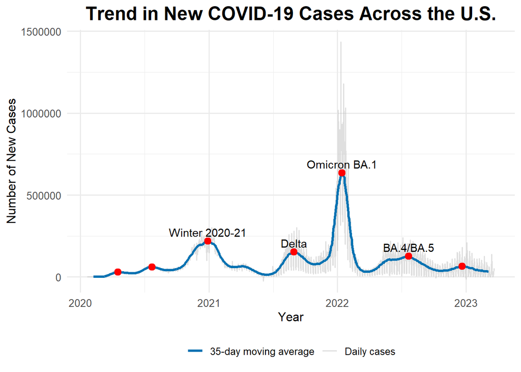

```r
daily_cases %>%
  ggplot(aes(x = date)) +
  geom_line(
    aes(y = new_case_count, color = "Daily cases"),
    alpha = 0.45,
    linewidth = 0.6
  ) +
  geom_line(
    data = daily_cases %>% drop_na(ma_35),
    aes(y = ma_35, color = "35-day moving average"),
    linewidth = 1.2,
    linetype = "solid"
  )  +
  geom_point(
    data = case_peak_35,
    aes(x = date, y = ma_35),
    inherit.aes = FALSE,
    color = "red",
    size = 2.8
  ) +
  geom_text_repel(
    data = case_peak_35_top4,
    aes(x = date, y = ma_35, label = label),
    inherit.aes = FALSE,
    direction = "y",
    nudge_y = 10000,
    max.overlaps = Inf
  ) +
  scale_color_manual(
    name = NULL,
    values = c(
      "Daily cases" = "#B8B8B8",
      "35-day moving average" = "#0072B2"
    )
  ) +
  labs(
    title = "Trend in New COVID-19 Cases Across the U.S.",
    x = "Year",
    y = "Number of New Cases"
  ) +
  theme_minimal(base_size = 12) +
  theme(
    plot.title = element_text(size = 18, face = "bold", hjust = 0.5),
    axis.title = element_text(size = 12),
    axis.text = element_text(size = 10),
    legend.position = "bottom"
  )
```

From the plot above, we can see that there are 6 minor spikes including the winter 2020-21 wave, delta wave, BA.4/BA.5 wave. And there is a major spike in January 2022 caused by Omicron BA.1.

For the states with the highest and lowest overall rates per persons, what differences do you see in their trajectories over time?

```r
covid19_rate <- covid19 %>%
    select(date, state, cases_avg_per_100k) %>%
    complete(
        state,
        date = seq(min(date), max(date), by = "day"),
        fill = list(cases_avg_per_100k = 0)
    ) %>%
    replace_na(list(cases_avg_per_100k = 0))
covid19_rate %>%
    group_by(state) %>%
    summarise(
        overall_rate = mean(cases_avg_per_100k),
        .groups = "drop"
    ) %>%
    filter(overall_rate == max(overall_rate) | overall_rate == min(overall_rate))
```

```
# A tibble: 2 × 2
  state        overall_rate
  <chr>               <dbl>
1 Maine                19.0
2 Rhode Island         37.4
```

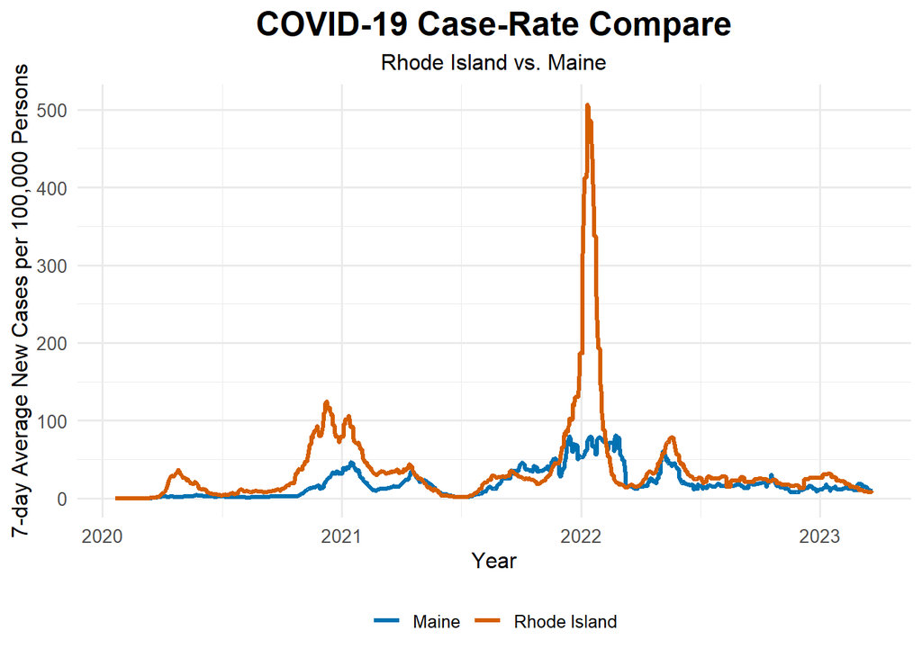

```r
covid19_rate %>%
  filter(state %in% c("Rhode Island", "Maine")) %>%
  ggplot(aes(x = date, y = cases_avg_per_100k, color = state)) +
  geom_line(linewidth = 1.2) +
  scale_color_manual(
    name = NULL,
    values = c(
      "Rhode Island" = "#D55E00",
      "Maine" = "#0072B2"
    )
  ) +
  scale_x_date(date_breaks = "1 year", date_labels = "%Y") +
  labs(
    title = "COVID-19 Case-Rate Compare",
    subtitle = "Rhode Island vs. Maine",
    x = "Year",
    y = "7-day Average New Cases per 100,000 Persons"
  ) +
  theme_minimal(base_size = 12) +
  theme(
    plot.title = element_text(size = 18, face = "bold", hjust = 0.5),
    plot.subtitle = element_text(size = 12, hjust = 0.5),
    axis.title = element_text(size = 12),
    axis.text = element_text(size = 10),
    legend.position = "bottom"
  )
```

```r
covid19_rate %>%
  filter(
    state %in% c("Rhode Island", "Maine"),
    date >= as.Date("2021-12-01"),
    date <= as.Date("2022-03-31")
  ) %>%
  group_by(state) %>%
  slice_max(cases_avg_per_100k, n = 1, with_ties = FALSE) %>%
  select(state, date, cases_avg_per_100k)
```

```
# A tibble: 2 × 3
# Groups:   state [2]
  state        date       cases_avg_per_100k
  <chr>        <date>                  <dbl>
1 Maine        2022-02-23               81.2
2 Rhode Island 2022-01-11              507.
```

Based on the given data, Rhode Island had the highest average reported case rate (37.39/100k) over the full study period, while Maine has the lowest (19.02/100k). And trajectory of Rhode Island was generally more pronounced with larger spikes, especially In early 2022. Maine’s rates were lower and its curve was flatter for much of the period.

These data show a difference in reported case rates. But we cannot infer that the states’ underlying infection trajectories differed. After searching related news, there are [reports indicate that Rhode Island mobilized National Guard members to support testing](https://www.providencejournal.com/story/news/local/2022/01/04/rhode-island-national-guard-called-out-rhode-island-governor-dan-mckee/9091649002/), which may have helped expand testing capacity. While, [Maine reported a backlog of positive test results](https://www.pressherald.com/2022/01/19/state-reports-1545-new-cases-of-covid-19-and-30-additional-deaths/), suggesting that its reported case counts may have been delayed or even incomplete. Thus, these data may not fully reflect the actual spread of COVID-19.

Identify, to the best of your ability without a formal test, the first five states to experience Covid in a substantial way.

```r
substantial <- merge(
    covid19 %>%
        filter(cases_avg_per_100k >= 50 / 7) %>%
        group_by(state) %>%
        slice_min(date, n = 1) %>%
        ungroup() %>%
        mutate(substantial_date = date) %>%
        select(state, substantial_date),
    covid19 %>%
        filter(cases > 0) %>%
        group_by(state) %>%
        slice_min(date, n = 1) %>%
        ungroup() %>%
        mutate(first_case_date = date) %>%
        select(state, first_case_date),
    by = 'state'
) %>%
    arrange(substantial_date) %>%
    mutate(state = factor(state, levels = rev(state)))
```

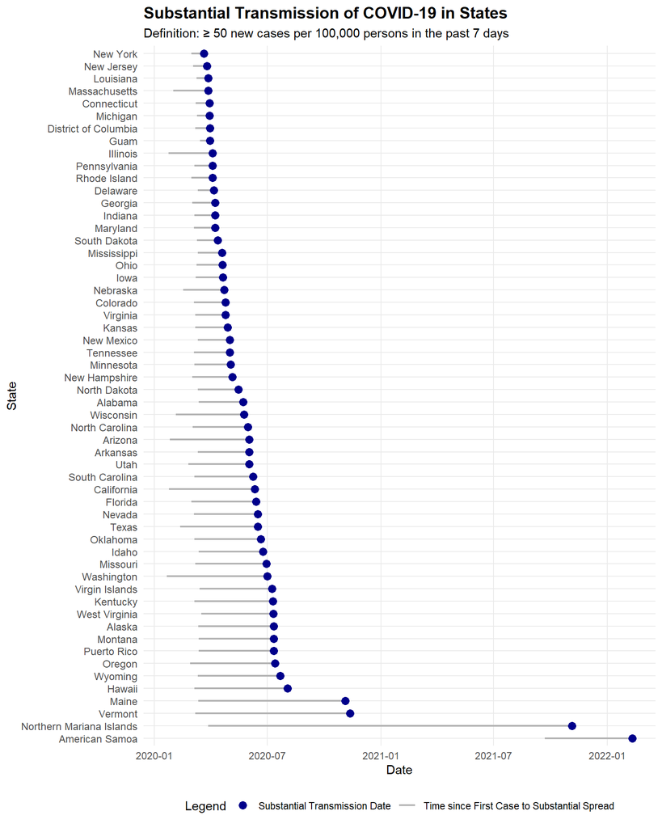

```r
ggplot(substantial, aes(y = state)) +
    geom_segment(aes(
        x = first_case_date, xend = substantial_date,
        y = state, yend = state,
        color = "Time since First Case to Substantial Spread"
    ),
        linewidth = 0.8) +
    geom_point(aes(
        x = substantial_date,
        color = "Substantial Transmission Date"
    ),
        size = 3
    ) +
    scale_color_manual(
      name = "Legend",
      values = c(
        "Time since First Case to Substantial Spread" = "grey70",
        "Substantial Transmission Date" = "darkblue"
      )
    ) +
    scale_x_date(
      limits = c(min(substantial$first_case_date), max(substantial$substantial_date)),
      date_labels = "%Y-%m"
    ) +
    labs(
      title = "Substantial Transmission of COVID-19 in States",
      subtitle = "Definition: ≥ 50 new cases per 100,000 persons in the past 7 days",
      x = "Date",
      y = "State"
    ) +
    theme_minimal() +
    theme(
      panel.grid.minor = element_blank(),
      plot.title = element_text(face = "bold", size = 14),
      axis.text.y = element_text(size = 9),
      legend.position = "bottom"
    )
```

Based on [the definition of thresholds for community transmission levels of SARS-CoV-2 by CDC](https://www.cdc.gov/mmwr/volumes/70/wr/mm7030e2.htm#T1_down), the transmission level is considered as “Substantial” when there are 50-99.99 new cases per 100,000 persons in the past 7 days. Therefore, we use the first date that at least 50 cases reported per 100k persons for each state in our analysis. And based on the data given in this repository, the first five states to experience Covid in a substantial way are:

1. New York
2. New Jersey
3. Louisiana
4. Massachusetts
5. Connecticut